# ISYE 6402 Homework 3 Solution

# Background

For this data analysis, you will analyze the daily closing price of The Coca-Cola Company (KO) at NYSE since 2015. The data can be read from *CocaColaStock.csv*. Here we use and compare different ways of fitting the ARIMA model with GARCH. Please note that in this data analysis you will perform lots of order selection and hence it may take several minutes for the file to knit.

```r
library(lubridate)
library(mgcv)
library(tseries)
library(car)
library(rugarch)
library(xts)
```

# Instructions on reading the data

To read the data in `R`, save the file in your working directory (make sure you have changed the directory if different from the R working directory) and read the data using the `R` function `read.csv()`

```r
stock <- read.csv("CocaColaStock.csv", header = TRUE)
stock$Date <- as.POSIXct(stock$Date)
```

# Question 1. Explanatory Data Analysis (7 points)

Transform the original closing price by taking the logarithm. Fit a non-parametric trend using splines together with ANOVA day-of-the-week seasonality. Plot the log-transformed time series together with the fitted values from modeling the trend and seasonality, and display the model summary. Are the trend and seasonality statistically significant?

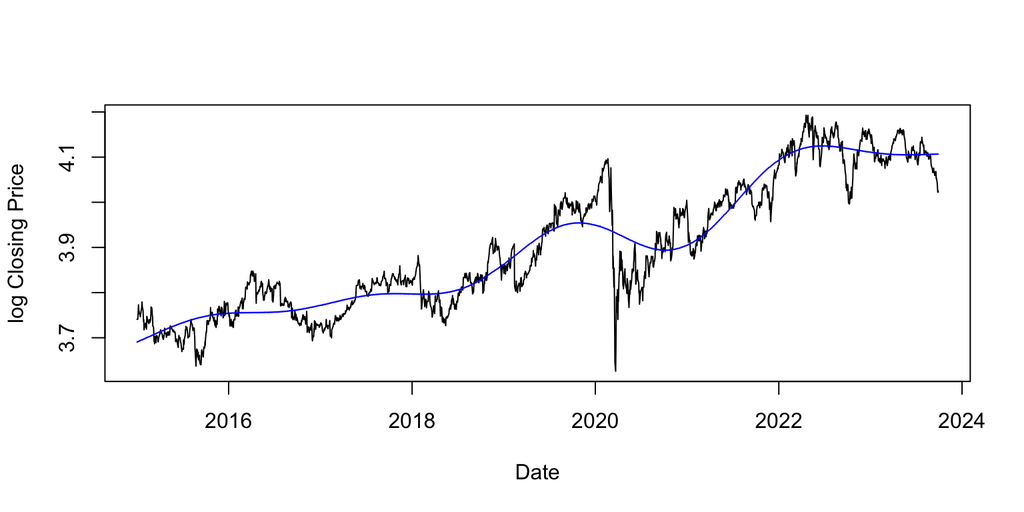

```r
logClose <- log(stock$KO.Close)
pts <- 1:length(logClose)
weekday <- as.factor(wday(stock$Date))
model1 <- gam(logClose ~ s(pts) + weekday)
plot(stock$Date, logClose, type = "l", xlab = "Date", ylab = "log Closing Price")
lines(stock$Date, fitted(model1), col = "blue")
```

```r
summary(model1)
```

```
##
## Family: gaussian
## Link function: identity
##
## Formula:
## logClose ~ s(pts) + weekday
##
## Parametric coefficients:
##               Estimate Std. Error  t value Pr(>|t|)
## (Intercept)  3.8993810  0.0023136 1685.405   <2e-16 ***
## weekday2     0.0008619  0.0031931    0.270    0.787
## weekday3     0.0002150  0.0031932    0.067    0.946
## weekday4    -0.0002127  0.0032016   -0.066    0.947
## weekday5     0.0002431  0.0032121    0.076    0.940
## ---
## Signif. codes:  0 '***' 0.001 '**' 0.01 '*' 0.05 '.' 0.1 ' ' 1
##
## Approximate significance of smooth terms:
##          edf Ref.df    F p-value
## s(pts) 8.994      9 2075  <2e-16 ***
## ---
## Signif. codes:  0 '***' 0.001 '**' 0.01 '*' 0.05 '.' 0.1 ' ' 1
##
## R-sq.(adj) =  0.895   Deviance explained = 89.5%
## GCV = 0.002203  Scale est. = 0.002189  n = 2201
```

*Response*: From the plot, we can see the stock price of Coca-Cola is slowly increasing over the years in general, apart from a sudden drop at the beginning of 2020. The model summary shows that the trend is statistically significant. The seasonal coefficients are not statistically significant given the trend in model, an indication that we don’t have significant seasonality.

# Question 2. Fitting ARIMA then GARCH. (40 points)

**2a. (ARIMA fitting and order selection)** Fit an ARIMA$(p,1,q)$ model with both $p$ and $q$ up to 8. For simplicity, select the best model based on AIC instead of AICc, and display the model summary. What is the selected order? What can you infer about the statistical significance of the ARIMA coefficients? (8 points)

```r
p <- 0:8
q <- 0:8
aic.arima <- matrix(0, length(p), length(q))
for (i in 1:length(p)) {
  for (j in 1:length(q)) {
    modij = arima(logClose, order = c(p[i], 1, q[j]), method = 'ML')
    aic.arima[i, j] = modij$aic
  }
}
```

```r
# Select the best order
js <- ceiling(which.min(aic.arima) / length(p))
is <- which.min(aic.arima) - (js-1)*length(p)
model.arima <- arima(logClose, order = c(p[is], 1, q[js]), method = "ML")
model.arima
```

```
##
## Call:
## arima(x = logClose, order = c(p[is], 1, q[js]), method = "ML")
##
## Coefficients:
##          ar1     ar2      ar3      ar4     ar5      ar6     ar7      ma1
##       0.7681  0.3959  -0.8482  -0.0705  0.1893  -0.1144  0.0145  -0.7742
## s.e.  0.0561  0.0860   0.0540   0.0339  0.0294   0.0348  0.0262   0.0521
##           ma2     ma3
##       -0.3745  0.8022
## s.e.   0.0833  0.0508
##
## sigma^2 estimated as 0.00013:  log likelihood = 6721.08,  aic = -13420.15
```

```r
# Z test
zvalue <- -abs(model.arima$coef/sqrt(diag(model.arima$var.coef)))
pvalue <- 2*pnorm(zvalue)
pvalue < 0.05
```

```
##   ar1   ar2   ar3   ar4   ar5   ar6   ar7   ma1   ma2   ma3
##  TRUE  TRUE  TRUE  TRUE  TRUE  TRUE FALSE  TRUE  TRUE  TRUE
```

*Response:* The selected model is ARIMA$(7,1,3)$. All coefficients are significant at level 0.05 except ar7.

**2b. (ARIMA residual analysis)** Plot the residual process of the model selected in 2a. Plot the ACF of the residual and the squared residual process. Is the residual process uncorrelated and/or independent from the ACF plots? Is there heteroskedasticity in the time series? (8 points)

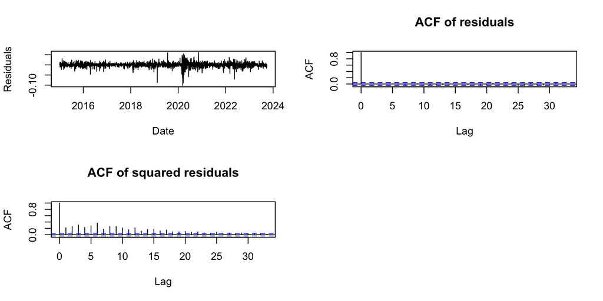

```r
par(mfrow=c(2,2))
plot(stock$Date, residuals(model.arima),type = "l", xlab = "Date", ylab = "Residuals")
acf(residuals(model.arima), main = "ACF of residuals")
acf(residuals(model.arima)^2, main = "ACF of squared residuals")
```

*Response:* The ACF of the residual process shows that the residuals are uncorrelated because there are no significant values outside the confidence band for lag $\geq 1$. However the ACF of the squared residuals show that there is serial correlation in this process, hence the residual process is NOT independent. The time series plot of the residual process itself also shows heteroskedasticity.

**2c. (GARCH fitting and order selection)** Use *tseries::garch()* to fit a GARCH$(p,q)$ model using the residual process of the model in 2a, for $p,q$ up to 5. Select the best model based on AIC and display the model summary. Comment on the statistical significance. Write down the equation for the fitted GARCH model. (8 points)

```r
# try different models and get AIC
p <- 0:5
q <- 0:5
aic.garch <- matrix(0, length(p), length(q))
aic.garch[1,1] = Inf
for (i in 1:length(p)) {
  for (j in 1:length(q)) {
    if (i>1 || j>1){
      modij = tseries::garch(residuals(model.arima), order = c(p[i], q[j]), trace = F)
      aic.garch[i, j] = AIC(modij)
    }
  }
}
```

```r
# Select the best order
js <- ceiling(which.min(aic.garch) / length(p))
is <- which.min(aic.garch) - (js-1)*length(p)
model.garch <- garch(residuals(model.arima), order = c(p[is], q[js]), trace = F)
summary(model.garch)
```

```
##
## Call:
## garch(x = residuals(model.arima), order = c(p[is], q[js]), trace = F)
##
## Model:
## GARCH(1,1)
##
## Residuals:
##      Min       1Q   Median       3Q      Max
## -9.40878 -0.51784  0.04638  0.59014  7.65437
##
## Coefficient(s):
##     Estimate  Std. Error  t value Pr(>|t|)
## a0 1.731e-06   2.442e-07    7.088 1.36e-12 ***
## a1 4.628e-02   3.553e-03   13.025  < 2e-16 ***
## b1 9.395e-01   3.812e-03  246.464  < 2e-16 ***
## ---
## Signif. codes:  0 '***' 0.001 '**' 0.01 '*' 0.05 '.' 0.1 ' ' 1
##
## Diagnostic Tests:
##  Jarque Bera Test
##
## data:  Residuals
## X-squared = 5395.5, df = 2, p-value < 2.2e-16
##
##
##  Box-Ljung test
##
## data:  Squared.Residuals
## X-squared = 0.19236, df = 1, p-value = 0.661
```

*Response:* The selected model is GARCH$(1,1)$, and both coefficients $\alpha_1,\beta_1$ are statistically significant as they have small p-values. The equation is:
$$\sigma_t^2 = 0.000 + 0.046 Z_{t-1}^2 + 0.940 \sigma_{t-1}^2$$

**2d. (GARCH residual analysis)** Display the ACF of the residuals and squared residuals of the GARCH model in 2c, as well as the QQ plot of the residuals. Comment on whether the GARCH model assumptions are satisfied. (8 points)

```
## [1] 1036 1145
```

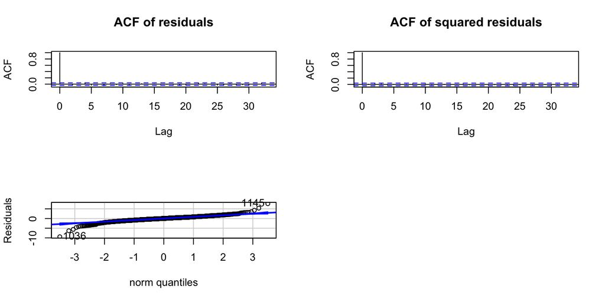

```r
par(mfrow=c(2,2))
acf(residuals(model.garch)[-c(1:max(p[is],q[is]))], main = "ACF of residuals")
acf(residuals(model.garch)[-c(1:max(p[is],q[is]))]^2, main = "ACF of squared residuals")
qqPlot(residuals(model.garch)[-c(1:max(p[is],q[is]))], ylab = "Residuals")
```

*Response:* Both ACF plots of the residuals show that residuals are not correlated, but the QQ plot shows that the conditional normality assumption is violated as the distribution has heavy tails. This is an indication that student-t distibution should be used to fit the models.

**2e. (GARCH fitting with other conditional distributions)** This time use *rugarch::ugarchfit()* to fit a GARCH model using the residual process of the ARIMA model fitted in 2a with the same GARCH order selected in 2c, and use t-distribution as the conditional distribution. Compare the fitted coefficients of this model with 2c. Display the QQ plot of model residuals against the fitted t-distribution and see if they satisfy the model assumption. (8 points)

(Hint: (1) Set the *armaOrder* to 0 and *include.mean* to *FALSE* in *ugarchspec* to fit only the GARCH model. (2) The residuals of the fitted *uGARCHfit* model can be accessed at *myGarchFit@fit$z*. Using *residuals()* on a *uGARCHfit* model returns the input time series for this question. (3) The degree of freedom of the fitted t-distribution is given by `shape’ in the *uGARCHfit* model coefficients.)

```r
spec = ugarchspec(variance.model=list(garchOrder=c(p[is],q[js])),
                mean.model=list(armaOrder=c(0,0), include.mean=F),
                distribution.model="std")
model.ugarch = ugarchfit(spec, residuals(model.arima), solver = 'hybrid')
sprintf("2(e) Model coefficients:")
```

```
## [1] "2(e) Model coefficients:"
```

```r
model.ugarch@fit$coef
```

```
##        omega       alpha1        beta1        shape
## 2.988812e-06 7.691285e-02 8.979540e-01 4.809472e+00
```

```r
sprintf("2(c) Model coefficients:")
```

```
## [1] "2(c) Model coefficients:"
```

```r
model.garch$coef
```

```
##           a0           a1           b1
## 1.730946e-06 4.627778e-02 9.394956e-01
```

```r
shape <- model.ugarch@fit$coef[4]
sprintf("Degree of Freedom: %f", shape)
```

```
## [1] "Degree of Freedom: 4.809472"
```

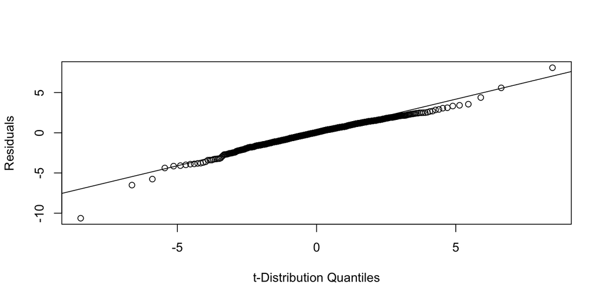

```r
l <- length(model.ugarch@fit$z)
qqplot(qt((1:l-0.5)/l, shape), model.ugarch@fit$z, xlab = "t-Distribution Quantiles",
       ylab = "Residuals")
qqline(model.ugarch@fit$z)
```

*Response:* The $\alpha_1$ coefficient of the two models in 2c and 2e are different, and this is because the specified conditional distributions for these two models are different. The comparison between the QQ plot here and 2d shows that it is more likely that the conditional distribution is a t-distribution.

# Question 3: Fitting ARMA together with GARCH (30 points)

For this question we consider the daily return of Cola-Cola stock in percentage to get rid of the trend, and split the data into training and testing set by leaving the last 10 days out for testing.

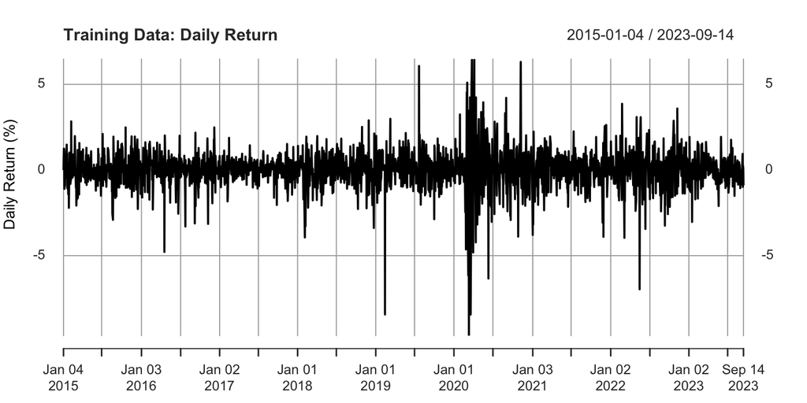

```r
dailyReturn <- diff(stock$KO.Close)/stock$KO.Close[-length(stock$KO.Close)]*100
dailyReturn <- xts(dailyReturn, order.by = stock$Date[-1])
training <- dailyReturn[1:(length(dailyReturn)-10)]
testing <- dailyReturn[(length(dailyReturn)-9):length(dailyReturn)]
par(mfrow=c(1,1))
plot(training, xlab = "Date", ylab = "Daily Return (%)", main = "Training Data: Daily Return")
```

**3a. (ARIMA-GARCH fitting and order selection)** Use *rugarch::ugarchfit* to fit a ARMA$(p,q)$-GARCH$(m,n)$ model for the daily return data for $p,q$ up to 8 and $m,n$ up to 3. Use student’s t-distribution as the conditional distribution model. Apply the iterative method to find the best model using AIC. Display the selected model. Does the selected model has the same order with Question 2? (10 points)

```r
p = 0:8
q = 0:8
m = 0:3
n = 0:3
## select ARMA order
aic.arma.garch1 <- matrix(0, length(p), length(q))
for (i in 1:length(p)) {
  for (j in 1:length(q)) {
      modij = arima(training, order = c(p[i], 0, q[j]), method = "ML")
      aic.arma.garch1[i, j] = AIC(modij)
  }
}
```

```r
j.arma <- ceiling(which.min(aic.arma.garch1) / length(p))
i.arma <- which.min(aic.arma.garch1) - (j.arma-1)*length(p)
sprintf("Selected order for ARMA: %d, %d", p[i.arma], q[j.arma])
```

```
## [1] "Selected order for ARMA: 7, 3"
```

```r
#model.arma.garch <- arima(training, order = c(p[i.arma], 0, q[j.arma]))
#model.arma.garch
```

```r
## select GARCH order
aic.arma.garch2 <- matrix(0, length(m), length(n))
for (i in 1:length(m)) {
  for (j in 1:length(n)) {
      spec = ugarchspec(variance.model=list(garchOrder=c(m[i],n[j])),
                mean.model=list(armaOrder=c(p[i.arma], q[j.arma]), include.mean=T),
                distribution.model="std")
      modij = ugarchfit(spec, data = training, solver = 'hybrid')
      aic.arma.garch2[i, j] = infocriteria(modij)[1]
  }
}
```

```r
j.garch <- ceiling(which.min(aic.arma.garch2) / length(m))
i.garch <- which.min(aic.arma.garch2) - (j.garch-1)*length(m)
sprintf("Selected order for GARCH: %d, %d", m[i.garch], n[j.garch])
```

```
## [1] "Selected order for GARCH: 2, 1"
```

```r
#spec <- ugarchspec(variance.model=list(garchOrder=c(m[i.garch],n[j.garch])),
#               mean.model=list(armaOrder=c(p[i.arma], q[j.arma]), include.mean=T),
#               distribution.model="std")
#model.arma.garch <- ugarchfit(spec, data = training, solver = 'hybrid')
#model.arma.garch
```

```r
## select ARMA order again
aic.arma.garch3 <- matrix(0, length(p), length(q))
for (i in 1:length(p)) {
  for (j in 1:length(q)) {
      spec = ugarchspec(variance.model=list(garchOrder=c(m[i.garch],n[j.garch])),
                mean.model=list(armaOrder=c(p[i], q[j]), include.mean=T),
                distribution.model="std")
      modij = ugarchfit(spec, data = training, solver = 'hybrid')
      aic.arma.garch3[i, j] = infocriteria(modij)[1]
  }
}
```

```r
j.arma <- ceiling(which.min(aic.arma.garch3) / length(p))
i.arma <- which.min(aic.arma.garch3) - (j.arma-1)*length(p)
sprintf("Selected order for ARMA: %d, %d", p[i.arma], q[j.arma])
```

```
## [1] "Selected order for ARMA: 7, 3"
```

```r
#spec <- ugarchspec(variance.model=list(garchOrder=c(m[i.garch],n[j.garch])),
#               mean.model=list(armaOrder=c(p[i.arma], q[j.arma]), include.mean=T),
#               distribution.model="std")
#model.arma.garch <- ugarchfit(spec, data = training, solver = 'hybrid')
#model.arma.garch
```

```r
# select GARCH order again. Actually since the ARMA order hasn't changed, we are only doing this for the completeness of the code.
aic.arma.garch4 <- matrix(0, length(m), length(n))
for (i in 1:length(m)) {
  for (j in 1:length(n)) {
      spec = ugarchspec(variance.model=list(garchOrder=c(m[i],n[j])),
                mean.model=list(armaOrder=c(p[i.arma], q[j.arma]), include.mean=T),
                distribution.model="std")
      modij = ugarchfit(spec, data = training, solver = 'hybrid')
      aic.arma.garch4[i, j] = infocriteria(modij)[1]
  }
}
```

```r
j.garch <- ceiling(which.min(aic.arma.garch4) / length(m))
i.garch <- which.min(aic.arma.garch4) - (j.garch-1)*length(m)
sprintf("Selected order for GARCH: %d, %d", m[i.garch], n[j.garch])
```

```
## [1] "Selected order for GARCH: 2, 1"
```

```r
spec <- ugarchspec(variance.model=list(garchOrder=c(m[i.garch],n[j.garch])),
                mean.model=list(armaOrder=c(p[i.arma], q[j.arma]), include.mean=T),
                distribution.model="std")
model.arma.garch <- ugarchfit(spec, data = training, solver = 'hybrid')
model.arma.garch@fit$coef
```

```
##            mu           ar1           ar2           ar3           ar4
##  6.045397e-02  5.601552e-01  2.805231e-01 -8.492089e-01 -5.518633e-02
##           ar5           ar6           ar7           ma1           ma2
##  3.107262e-02 -4.810007e-02  5.652507e-03 -6.155622e-01 -2.767622e-01
##           ma3         omega        alpha1        alpha2         beta1
##  8.721634e-01  2.632115e-02  7.579445e-02  1.399097e-11  9.003933e-01
##         shape
##  4.725640e+00
```

*Response:* The final selected model is ARMA(7,3)-GARCH(2,1) and does not have the same order as the model in Question 2. This difference is because: (1) We are using different data (residual process after fitting the trend vs differenced data); (2) We fit ARMA together with GARCH instead of separately; and (3) We are using student’s t-distribution instead of normal as the conditional distribution. The fitted degree of freedom for the t-distribution is 4.726 which is quite small indicating a heavy tail distribution; in other words the fitted conditional distribution is different from the normal distribution assumed in Question 2.

**3b. (Residual analysis)** Plot the residual process $(\hat Z_t)$ and the standardized residual process $(\hat Z_t / \hat\sigma_t)$. Display the ACF of both the un-standardized and standardized residuals, and the ACFs of the squared residual processes (four ACF plots in total). Comment on your observations based on these plots. (10 points)

(Hint: Same with 2e, *residuals()* on a *uGARCHfit* model returns the un-standardized residuals of the ARMA model (the $\hat Z_t$). The standardized residuals $\hat Z_t / \hat\sigma_t$ can be accessed using *myGarchFit@fit$z*, where $\hat\sigma_t^2$ is the estimated conditional variance by GARCH.)

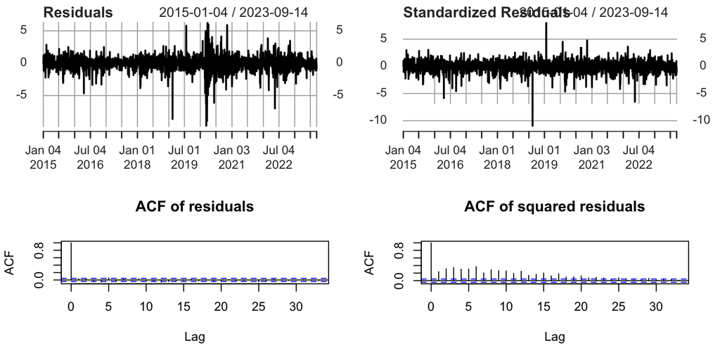

```r
par(mfrow=c(2,2))
plot(residuals(model.arma.garch), main = "Residuals")
plot(xts(model.arma.garch@fit$z, order.by = index(training)), main = "Standardized Residuals")
acf(as.numeric(residuals(model.arma.garch)), main = "ACF of residuals")
acf(as.numeric(residuals(model.arma.garch)^2), main = "ACF of squared residuals")
```

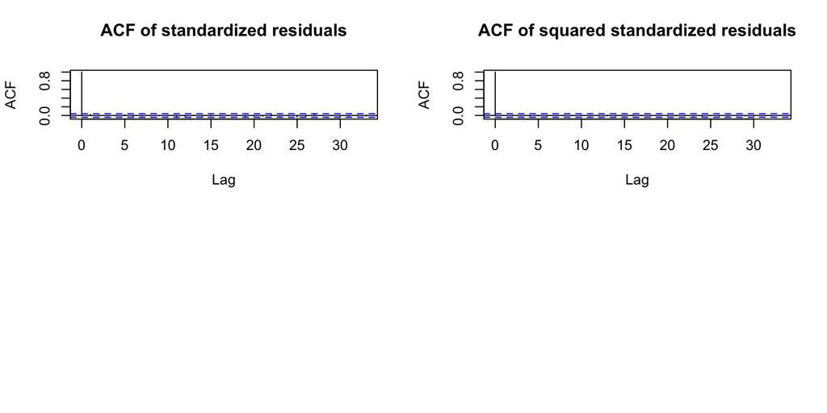

```r
acf(model.arma.garch@fit$z, main = "ACF of standardized residuals")
acf(model.arma.garch@fit$z^2, main = "ACF of squared standardized residuals")
```

*Response:* From the plot of the residual processes, we can clearly see that the un-standardized residual process have a cluster of large variance around the beginning of 2020, while the standardized residual process doesn’t have obvious clusters. The ACF of the un-standardized residuals shows no correlation and the ARMA model successfully models the correlations of the mean process. The squared un-standardized residuals have serial correlation which can be seen from the ACF plot. This is why we should have GARCH to model the conditional variance of the process. The standardized residuals show no more serial correlations in both ACF plots. So it seems the GARCH model is able to capture the change in conditional variance.

**3c. (Forecasting)** Apply the selected model in 3a and forecast the return of the remaining 10 days. For each iteration, predict one step ahead, then retrain the model by adding the newly observed daily return to predict the next. Plot the actual daily return for these 10 days together with the predicted values and the 95% confidence interval using the predicted conditional variance. Comment on your observations. (10 points)

```r
nfore = 10
fore.series = NULL
fore.sigma = NULL
for(f in 1: nfore){
        #Fit models
        data = training
        if(f > 1)
            data = c(training,testing[1:(f-1)])
        model.forecast = ugarchfit(spec, data, solver = 'hybrid')
        #Forecast
        fore = ugarchforecast(model.forecast, n.ahead=1)
        fore.series = c(fore.series, fore@forecast$seriesFor)
        fore.sigma = c(fore.sigma, fore@forecast$sigmaFor)
}
```

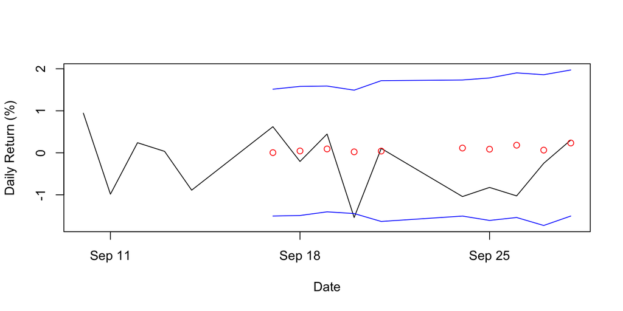

```r
# Plot
par(mfrow=c(1,1))
ylim <- c(min(fore.series - 1.96*fore.sigma), max(fore.series + 1.96*fore.sigma))
plot(index(dailyReturn[(length(dailyReturn)-14):length(dailyReturn)]),
     dailyReturn[(length(dailyReturn)-14):length(dailyReturn)],
     type = "l", xlab = "Date", ylab = "Daily Return (%)", ylim = ylim)
points(index(dailyReturn[(length(dailyReturn)-nfore+1):length(dailyReturn)]),
       fore.series, col = "red")
lines(index(dailyReturn[(length(dailyReturn)-nfore+1):length(dailyReturn)]),
      fore.series + 1.96*fore.sigma, col = "blue")
lines(index(dailyReturn[(length(dailyReturn)-nfore+1):length(dailyReturn)]),
      fore.series - 1.96*fore.sigma, col = "blue")
```

*Response:* The predicted values and confidence intervals are able to cover the actual daily return for most days. Though they are not very informative in providing a good investment strategy.

# Question 4. Other GARCH models (8 points)

Fit the training data in Question 3 using *rugarch::ugarchfit()* with two of the other GARCH models (eGARCH, apARCH, iGARCH etc.) of your choice using t-distribution as conditional distribution. You don’t need to select the ARMA and GARCH order again, just use the order in Question 3a. Predict the daily return of the remaining 10 days using these two models, and compare the prediction accuracies based on these models and that in Question 3 using Mean Squared Prediction Error (MSPE) and Mean Absolute Prediction Error (MAE). What is the appropriate measure of prediction accuracy to be used in comparing the predictions? Provide the reasoning behind your selection.

```r
# Here I choose eGARCH and iGARCH.
spec.2 <- ugarchspec(variance.model=list(model = "eGARCH", garchOrder=c(m[i.garch],n[j.garch])),
                mean.model=list(armaOrder=c(p[i.arma], q[j.arma]), include.mean=T),
                distribution.model="std")
spec.3 <- ugarchspec(variance.model=list(model = "iGARCH", garchOrder=c(m[i.garch],n[j.garch])),
                mean.model=list(armaOrder=c(p[i.arma], q[j.arma]), include.mean=T),
                distribution.model="std")

# Forecast using ARMA-eGARCH and ARMA-iGARCH
nfore = 10
fore.series.2 = NULL
fore.series.3 = NULL
for(f in 1: nfore){
        #Fit models
        data = training
        if(f > 1)
            data = c(training,testing[1:(f-1)])
        model.forecast.2 = ugarchfit(spec.2, data, solver = 'hybrid')
        model.forecast.3 = ugarchfit(spec.3, data, solver = 'hybrid')
        #Forecast
        fore.2 = ugarchforecast(model.forecast.2, n.ahead=1)
        fore.3 = ugarchforecast(model.forecast.3, n.ahead=1)
        fore.series.2 = c(fore.series.2, fore.2@forecast$seriesFor)
        fore.series.3 = c(fore.series.3, fore.3@forecast$seriesFor)
}
```

```r
# Compare MSPE
sprintf("MSPE of standard GARCH: %f", mean((fore.series - testing)^2))
```

```
## [1] "MSPE of standard GARCH: 0.674083"
```

```r
sprintf("MSPE of eGARCH: %f", mean((fore.series.2 - testing)^2))
```

```
## [1] "MSPE of eGARCH: 0.674221"
```

```r
sprintf("MSPE of iGARCH: %f", mean((fore.series.3 - testing)^2))
```

```
## [1] "MSPE of iGARCH: 0.665434"
```

```r
# Compare MAE
sprintf("MAE of standard GARCH: %f", mean(abs(fore.series - testing)))
```

```
## [1] "MAE of standard GARCH: 0.650652"
```

```r
sprintf("MAE of eGARCH: %f", mean(abs(fore.series.2 - testing)))
```

```
## [1] "MAE of eGARCH: 0.644418"
```

```r
sprintf("MAE of iGARCH: %f", mean(abs(fore.series.3 - testing)))
```

```
## [1] "MAE of iGARCH: 0.641008"
```

*Response:* According to both MSPE and MAE, iGARCH has the best prediction. A possible explantion is that iGARCH model can capture the unstationarity in the conditional variance and thus lead to better prediction of the mean response. Because we use a student-t distribution, the absolute value measures would be most appropriate in comparing the prediction accuracies.

# Question 5. (15 points)

**5a.** Expand on the derivation of the 3-step ahead predictions of an estimated ARMA(1,2)-GARCH(2,1) model using the recursive approach. (5 points)

*Response:* Let $\hat \mu, \hat \phi_1,\hat\theta_1,\hat \theta_2$ be the coefficients of the fitted ARMA(1,2) and $\hat \gamma_0,\hat\gamma_1,\hat\gamma_2,\hat \beta_1$ be the coefficients of the fitted GARCH(2,1). (In the model summary of *ugarchfit()*, they are called mu, ar1, ma1, ma2, omega, alpha1, alpha2, beta1 respectively.)

Step 1: Forecast the conditional mean using alternative regressor such as the linear process in Module 1:
$$\hat Y_{T+h} = P_TY_{T+h} \text{ for } h = 1,2,3.$$

Step 2: Compute the conditional variance recursively: for time $T+1$,
$$\hat\sigma_{T+1}^2 = \hat\gamma_0 + \hat\gamma_1 \hat Z_{T}^2 +
\hat\gamma_2\hat Z_{T-1}^2 + \hat\beta_1\sigma_T^2.$$

For time $T+2$,
$$\hat Z_{T+1} = \hat Y_{T+1}- (\hat\mu + \hat\phi_1 \hat Y_T
+\hat\theta_1 \hat Z_T + \hat \theta_2 \hat Z_{T-1}),$$
and
$$\hat\sigma_{T+2}^2 = \hat\gamma_0 + \hat\gamma_1 \hat Z_{T+1}^2 +
\hat\gamma_2\hat Z_{T}^2 + \hat\beta_1\sigma_{T+1}^2.$$

For time $T+3$,
$$\hat Z_{T+2} = \hat Y_{T+2}- (\hat\mu + \hat\phi_1 \hat Y_{T+1}
+\hat\theta_1 \hat Z_{T+1} + \hat \theta_2 \hat Z_{T}),$$
and
$$\hat\sigma_{T+3}^2 = \hat\gamma_0 + \hat\gamma_1 \hat Z_{T+2}^2 +
\hat\gamma_2\hat Z_{T+1}^2 + \hat\beta_1\sigma_{T+2}^2.$$

**5b.** Derive the conditions of stationarity for an ARCH(2) model. (5 points)

*Response:* The weak stationarity requires that the variance $\mathbb E[Z_t^2] = \mathbb E[\sigma_t^2]$ is finite. By the ARCH(2) model we have
$$\sigma_t^2 = \gamma_0 + \gamma_1 Z_{t-1}^2 + \gamma_2 Z_{t-2}^2.$$
To make sure the conditional variance on the left hand side is non-negative, there should be $\gamma_0,\gamma_1,\gamma_2 \geq 0$. Taking expectation of both sides,
$$\mathbb E[\sigma_t^2] = \gamma_0 + \gamma_1 \mathbb E[Z_{t-1}^2] +
\mathbb E[\gamma_2 Z_{t-2}^2] = \gamma_0 + (\gamma_1 + \gamma_2)\mathbb
E[\sigma_t^2],$$
Moving $(\gamma_1 + \gamma_2)\mathbb E[\sigma_t^2]$ to the left, we have
$$(1-\gamma_1-\gamma_2) \mathbb E[\sigma_t^2] = \gamma_0,$$
and
$$\mathbb E[\sigma_t^2] = \frac{\gamma_0}{1-\gamma_1-\gamma_2}.$$
Again the variance must be non-negative, so the above result only makes sense when $\gamma_0/(1-\gamma_1-\gamma_2) \geq 0.$ So together the condition is
$$\begin{split}
&\gamma_0, \gamma_1,\gamma_2 \geq 0,\\
&\gamma_1 + \gamma_2 < 1.
\end{split}$$

**5c.** Provide an example illustrating why estimating conditional mean and conditional variance jointly is more effective than estimating separately. (5 points)

*Response:* 1. The order selected by fitting ARMA then GARCH is often higher than fitting together, especially when the conditional variation varies a lot in the ARMA-GARCH model. Below is an numerical example where I generate an ARMA(0,0)-GARCH(1,0) time series with $\gamma_1 = 0.8$ such that the process is still weakly stationary but the kurtosis is not finite. The order selected by ARMA alone using AIC is ARMA(2,1) and the order selected by jointly fitting them is ARMA(0,0)-GARCH(1,0). 2. We can get more reliable statistical inference since fitting jointly accounts for the fluctuation in the conditional variance.

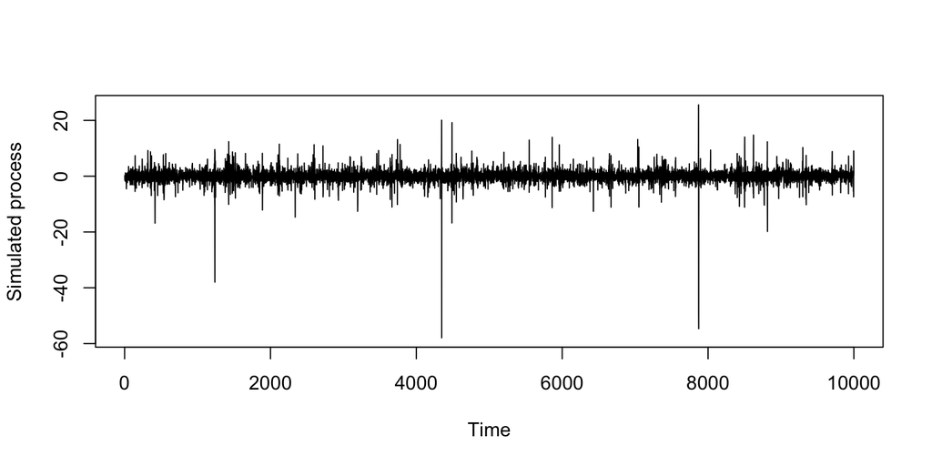

```r
# Generate GARCH(1,0) time series
set.seed(10)
z <- rnorm(10000)
my.sigma2 <- rep(0,10000)
my.sigma2[1] <- 1
for (i in 2:10000){
  my.sigma2[i] <- 1 + 0.8*my.sigma2[i-1]*z[i-1]*z[i-1]
}
my.process <- z*sqrt(my.sigma2)
plot(my.process, type = "l", xlab = "Time", ylab = "Simulated process")
```

```r
# ARMA order selection.
p = 0:2
q = 0:2
m = 0:1
n = 0:1
## select ARMA order
aic.arma.garch1 <- matrix(0, length(p), length(q))
for (i in 1:length(p)) {
  for (j in 1:length(q)) {
      modij = arima(my.process, order = c(p[i], 0, q[j]), method = "ML")
      aic.arma.garch1[i, j] = AIC(modij)
  }
}
j.arma <- ceiling(which.min(aic.arma.garch1) / length(p))
i.arma <- which.min(aic.arma.garch1) - (j.arma-1)*length(p)
sprintf("Selected order for ARMA: %d, %d", p[i.arma], q[j.arma])
```

```
## [1] "Selected order for ARMA: 2, 1"
```

```r
## select GARCH order by fixing ARMA order
aic.arma.garch2 <- matrix(0, length(m), length(n))
aic.arma.garch2[1,1] <- Inf
for (i in 1:length(m)) {
  for (j in 1:length(n)) {
    if (i>1 | j>1){
      spec = ugarchspec(variance.model=list(garchOrder=c(m[i],n[j])),
                mean.model=list(armaOrder=c(p[i.arma], q[j.arma]), include.mean=T),
                distribution.model="norm")
      modij = ugarchfit(spec, data = my.process, solver = 'hybrid')
      aic.arma.garch2[i, j] = infocriteria(modij)[1]
    }
  }
}
j.garch <- ceiling(which.min(aic.arma.garch2) / length(m))
i.garch <- which.min(aic.arma.garch2) - (j.garch-1)*length(m)
sprintf("Selected order for GARCH: %d, %d", m[i.garch], n[j.garch])
```

```
## [1] "Selected order for GARCH: 1, 0"
```

```r
## select ARMA order again by fixing GARCH order
aic.arma.garch3 <- matrix(0, length(p), length(q))
for (i in 1:length(p)) {
  for (j in 1:length(q)) {
      spec = ugarchspec(variance.model=list(garchOrder=c(m[i.garch],n[j.garch])),
                mean.model=list(armaOrder=c(p[i], q[j]), include.mean=T),
                distribution.model="norm")
      modij = ugarchfit(spec, data = my.process, solver = 'hybrid')
      aic.arma.garch3[i, j] = infocriteria(modij)[1]
  }
}
j.arma <- ceiling(which.min(aic.arma.garch3) / length(p))
i.arma <- which.min(aic.arma.garch3) - (j.arma-1)*length(p)
sprintf("Selected order for ARMA: %d, %d", p[i.arma], q[j.arma])
```

```
## [1] "Selected order for ARMA: 0, 0"
```

```r
# select GARCH order again.
aic.arma.garch4 <- matrix(0, length(m), length(n))
aic.arma.garch4[1,1] <- Inf
for (i in 1:length(m)) {
  for (j in 1:length(n)) {
    if (i>1 | j>1){
      spec = ugarchspec(variance.model=list(garchOrder=c(m[i],n[j])),
                mean.model=list(armaOrder=c(p[i.arma], q[j.arma]), include.mean=T),
                distribution.model="norm")
      modij = ugarchfit(spec, data = my.process, solver = 'hybrid')
      aic.arma.garch4[i, j] = infocriteria(modij)[1]
    }
  }
}
j.garch <- ceiling(which.min(aic.arma.garch4) / length(m))
i.garch <- which.min(aic.arma.garch4) - (j.garch-1)*length(m)
sprintf("Selected order for GARCH: %d, %d", m[i.garch], n[j.garch])
```

```
## [1] "Selected order for GARCH: 1, 0"
```

```r
# Final model:
spec <- ugarchspec(variance.model=list(garchOrder=c(m[i.garch],n[j.garch])),
                mean.model=list(armaOrder=c(p[i.arma], q[j.arma]), include.mean=T),
                distribution.model="norm")
model.arma.garch <- ugarchfit(spec, data = my.process, solver = 'hybrid')
model.arma.garch@fit$coef
```

```
##          mu       omega      alpha1
## -0.01316224  0.99076868  0.82970999
```